# LUNGS CANCER RISK PREDICTION

### SELECTION OF THE MODEL

We are going to select the model with the variables that we found interesting and with a pretty good accuracy before.

```r
model = Risk ~ Genetic.Risk + OccuPational.Hazards + chronic.Lung.Disease + Obesity + Alcohol.use
linFit <- lm(model, data=XTrain)
```

**Now we have to select the best model**

```r
modelresult = ols_step_all_possible(linFit) #We store all the possible subsets just in case.
ols_step_best_subset(linFit)
```

[output not shown]

*We can now plot some interesting graphs about tose models*

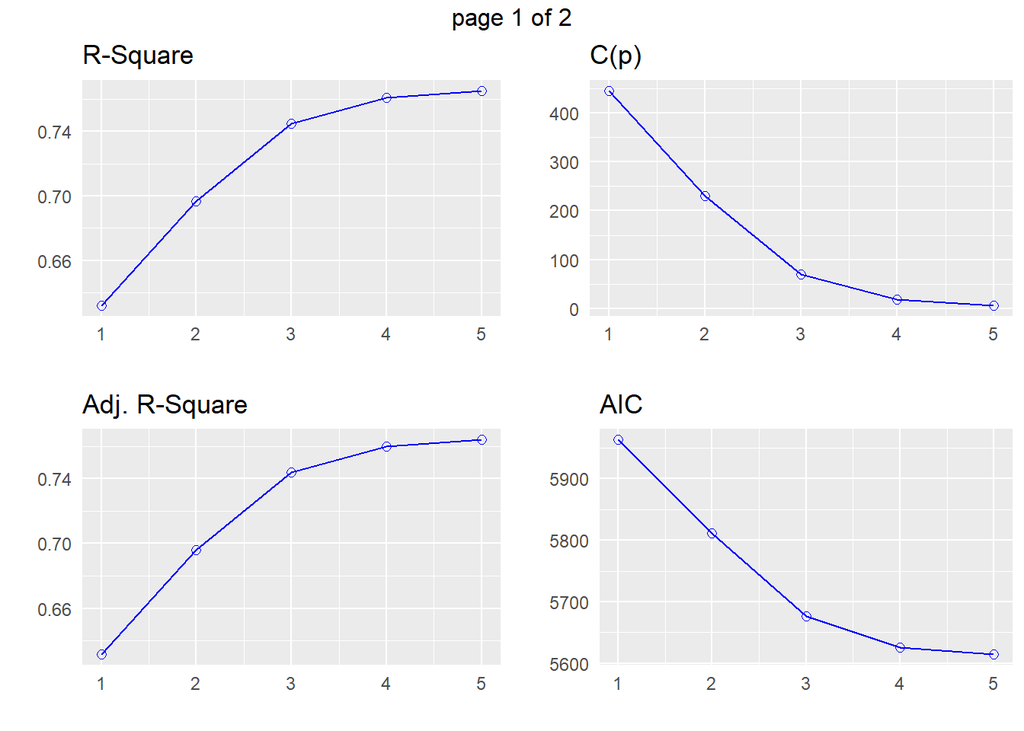

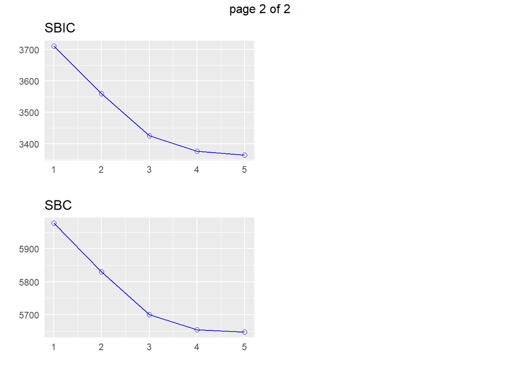

```r
plot(ols_step_forward_p(linFit))
```

We can see that the higher the model the higher the accuracy and the lower the errors that makes of it a very accurate model but also potentially an over fitted one.

### Statistical learning tools in REGRESSION

*Until now we had used a very easy to understand regression prediction. To find a model. We could easy change the variables taken into account. Now with the statistical learning tools we should be able to compute more accurate models and compare different precisions in order to find the best model.* We are going to use a control function for our models.

```r
ctrl <- trainControl(method = "repeatedcv",
                     number = 5, repeats = 2)
```

This function will repeat the process two times of creating 5 diferent training sets. This is use with caret in order to avoid having over fitted model for a training set, we create and test several training set as if we had ” bigger data”.

### LINEAR REGRESSION

We are going to create a vector where we store the results of the test. At first we fill it with the values of the Risk.

```r
test_results <- data.frame(Risk = XTest$Risk)
```

We are going to try first with a linear regression model.

```r
lm_tune <- train(model, data = XTrain,
                 method = "lm",
                 preProc=c("scale", "center"),
                 trControl = ctrl)
lm_tune
```

```
## Linear Regression
##
## 793 samples
##   5 predictor
##
## Pre-processing: scaled (5), centered (5)
## Resampling: Cross-Validated (5 fold, repeated 2 times)
## Summary of sample sizes: 635, 634, 635, 634, 634, 634, ...
## Resampling results:
##
##   RMSE     Rsquared   MAE
##   8.31338  0.7639218  6.536199
##
## Tuning parameter 'intercept' was held constant at a value of TRUE
```

```r
test_results$lm <- predict(lm_tune, XTest)
postResample(pred = test_results$lm,  obs = test_results$Risk)
```

```
##      RMSE  Rsquared       MAE
## 8.3033269 0.7522868 6.2024016
```

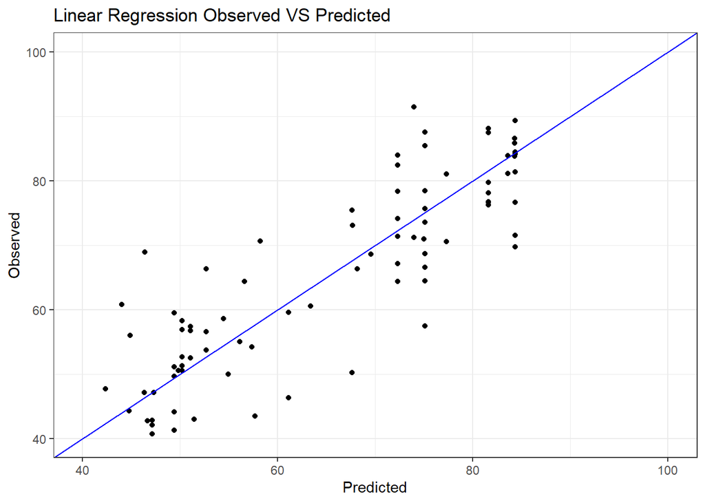

```r
qplot(test_results$lm, test_results$Risk) +
  labs(title="Linear Regression Observed VS Predicted", x="Predicted", y="Observed") +
  lims(x = c(40, 100), y = c(40,100)) +
  geom_abline(intercept = 0, slope = 1, colour = "blue") +
  theme_bw()
```

*We can see a bias. But it is even more interesting that we can perfectly differentiate the three levels.We can also add taht the values with higher Risk are more easy to predict than the other ones.*

### Overfitted linear regression

We can try an over fitted model that for sure is not going to be the most useful one but it can be interesting to compare it with other models.

```r
alm_tune <- train(model, data = XTrain,
                  method = "lm",
                  preProc=c('scale', 'center'),
                  trControl = ctrl)
```

```r
test_results$alm <- predict(alm_tune, XTest)
postResample(pred = test_results$alm,  obs = test_results$Risk)
```

```
##      RMSE  Rsquared       MAE
## 8.3033269 0.7522868 6.2024016
```

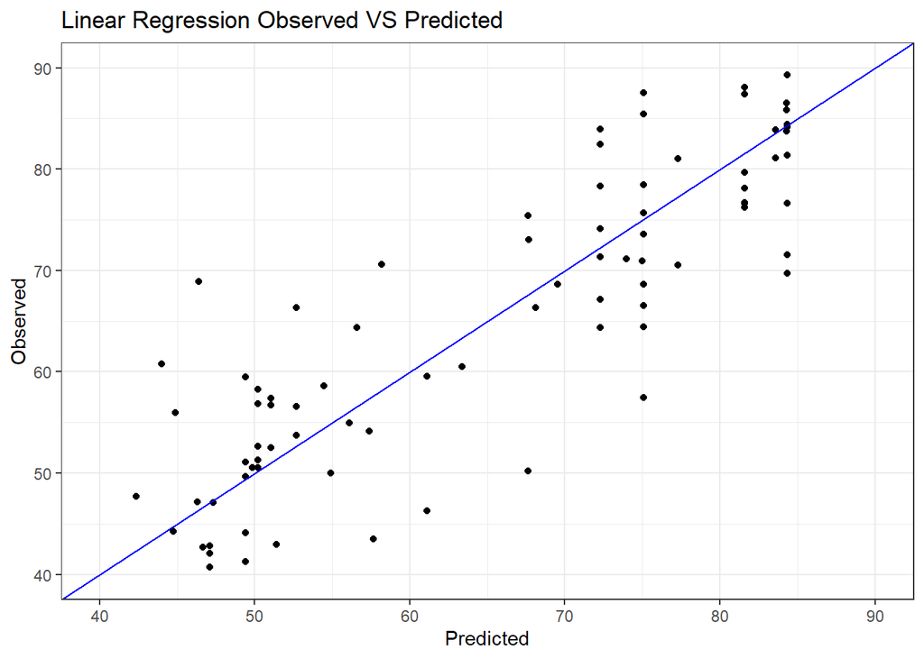

```r
qplot(test_results$alm, test_results$Risk) +
  labs(title="Linear Regression Observed VS Predicted", x="Predicted", y="Observed") +
  lims(x = c(40, 90), y = c(40, 90)) +
  geom_abline(intercept = 0, slope = 1, colour = "blue") +
  theme_bw()
```

The difference between the two models is not so big. We have less bias and same Rsquared just because we have a more over fitted model but that does not give us exactly more accuracy.

### Foward Regression

Once we have used linear regression we can test the foward regression which consist in starting with a empty model and adding variables one by one, this bethod belongs to the stepwise regression methods, with change the model step by step. In this case we are going to use the model with all the variables. To be able to understant how many are relevant enought.

```r
for_tune <- train(modelall, data = XTrain,
                  method = "leapForward",
                  preProc=c('scale', 'center'),tuneGrid = expand.grid(nvmax = 4:22), trControl = ctrl)
```

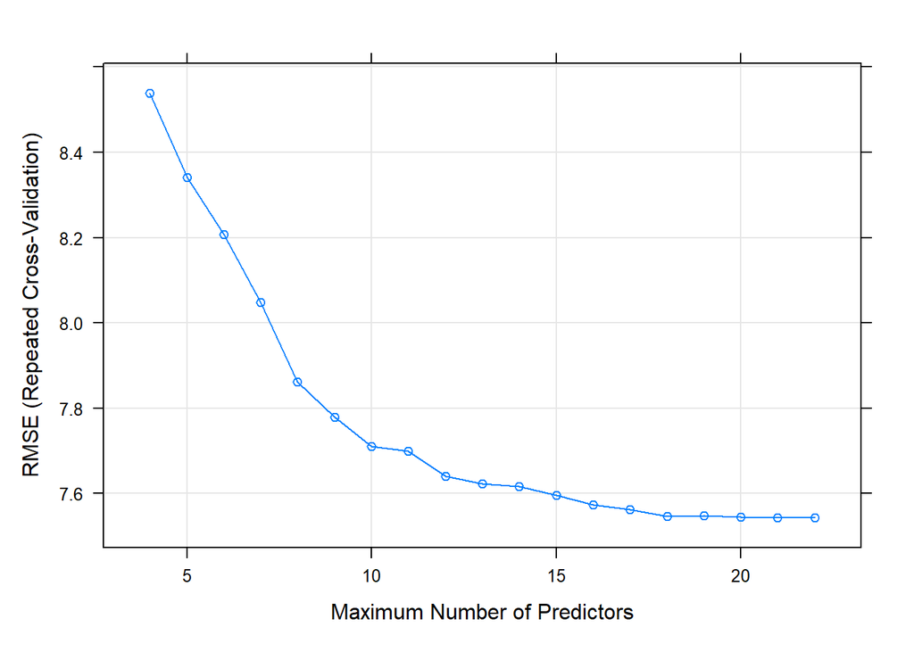

```r
plot(for_tune)
```

We can clearly see that teh more variables the best. In fact, this is true until the 18th variable. We are now going to see which ones are the most relevant ones.

```r
coef(for_tune$finalModel, for_tune$bestTune$nvmax)
```

```
##              (Intercept)             Genetic.Risk     OccuPational.Hazards
##              64.56442623               0.79721570              -1.31824657
##     chronic.Lung.Disease                  Obesity                   Gender
##               2.30342960               2.44528841              -1.42215398
##            Air.Pollution              Alcohol.use             Dust.Allergy
##               0.78511234               5.65487370              -0.65829291
##            Balanced.Diet                  Smoking           Passive.Smoker
##               1.39442575               2.50706324              -0.35792661
##               Chest.Pain        Coughing.of.Blood                  Fatigue
##               1.11035640               1.30596697               1.77669179
##              Weight.Loss      Shortness.of.Breath    Swallowing.Difficulty
##               2.50274782              -0.84678687               0.05445203
## Clubbing.of.Finger.Nails            Frequent.Cold                Dry.Cough
##               0.92870688               0.70389751               1.94329782
##                  Snoring
##              -1.22176631
```

Those are the most relevant variables.

```r
lr_imp <- varImp(for_tune , scale = F)
plot(lr_imp, scales = list(y = list(cex = .95)))
```

[output not shown]

```r
test_results$seq <- predict(for_tune, XTest)
postResample(pred = test_results$seq,  obs = test_results$Risk)
```

```
##      RMSE  Rsquared       MAE
## 7.4005203 0.8022115 6.0216787
```

*We can observe a considerably higher Rsquared than in the previous models and a lower RMSE. We will always choose this model over the previous ones. We have also the most relevant variables and it could be interesting to compare them with the ones of the backward regression.*

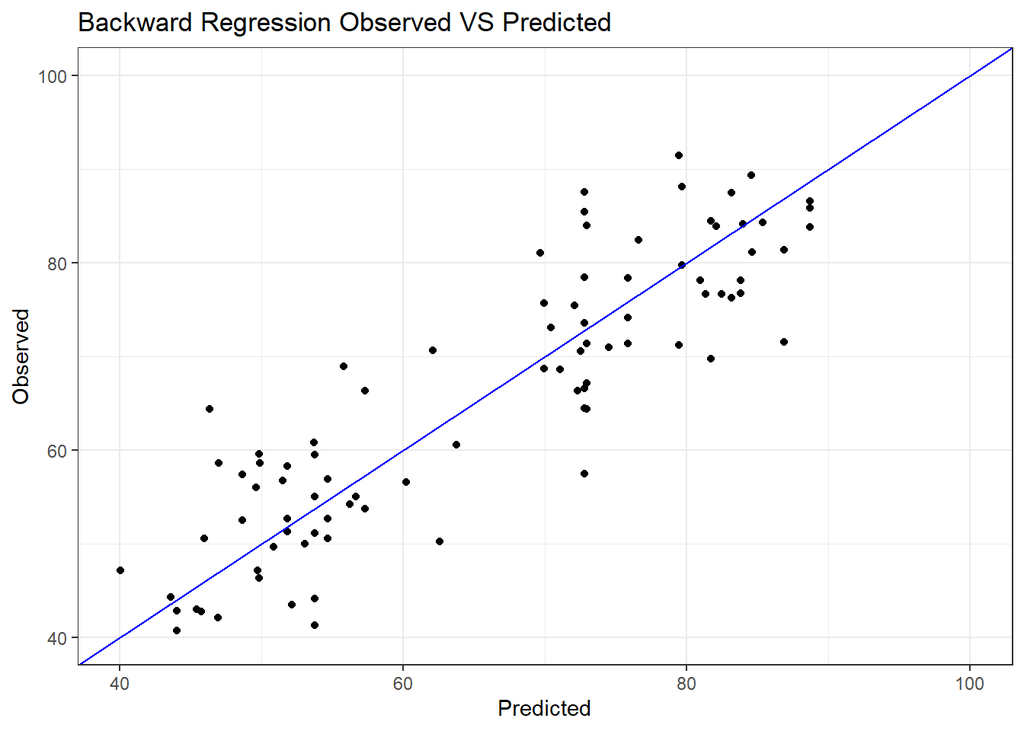

```r
test_results$bw <- predict(for_tune, XTest)
qplot(test_results$bw, test_results$Risk) +
  labs(title="Backward Regression Observed VS Predicted", x="Predicted", y="Observed") +
  lims(x = c(40,100), y = c(40,100)) +
  geom_abline(intercept = 0, slope = 1, colour = "blue") +
  theme_bw()
```

### Backawrd regression

This kind of regression also belongs to the same kind of step wise regression. But this time instead of adding the variable we start with all the variables and we take them out one by one.

```r
back_tune <- train(modelall, data = XTrain,
                  method = "leapBackward",
                  preProc=c('scale', 'center'),tuneGrid = expand.grid(nvmax = 4:22), trControl = ctrl)
```

We are going to plot how many variables make the more accuracy.

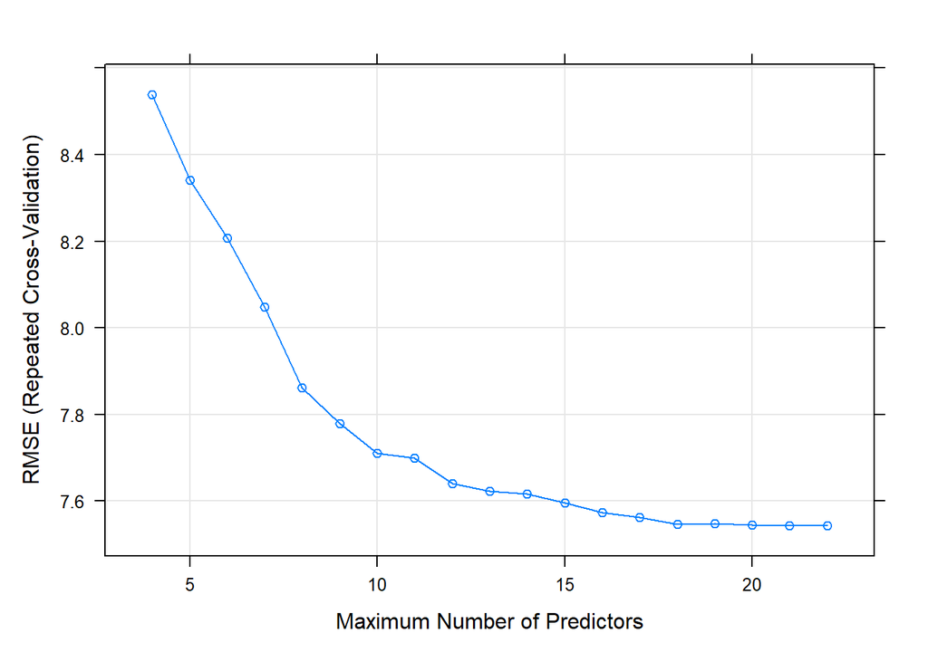

```r
plot(for_tune)
```

```r
lr_imp <- varImp(back_tune , scale = F)
plot(lr_imp, scales = list(y = list(cex = .95)))
```

### STEP-wise regression

This kind of regression is also made in steps as the previous ones. It first test linear variables then crosses the products. We want to know if this kind of study is better or not in prediction.

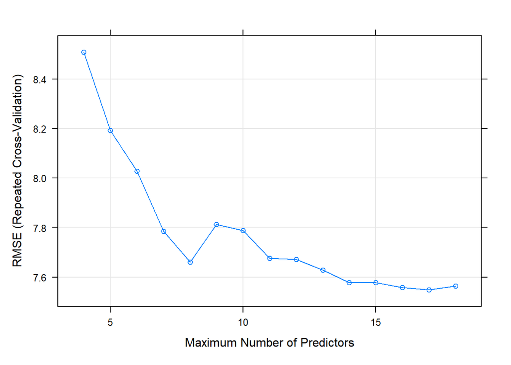

```r
step_tune <- train(modelall, data = XTrain,
                   method = "leapSeq",
                   preProc=c('scale', 'center'),
                   tuneGrid = expand.grid(nvmax = 4:18),
                   trControl = ctrl)
plot(step_tune)
```

```r
coef(step_tune$finalModel, step_tune$bestTune$nvmax)
```

```
##           (Intercept)          Genetic.Risk  OccuPational.Hazards
##            64.5644262            -0.6646807            -1.7991890
##  chronic.Lung.Disease               Obesity                Gender
##             4.1595074             3.3854788            -1.2720998
##         Air.Pollution           Alcohol.use          Dust.Allergy
##             1.5997538             5.3581728             0.3167446
##         Balanced.Diet               Smoking        Passive.Smoker
##             2.5938804             1.7351827            -0.8029113
##            Chest.Pain     Coughing.of.Blood               Fatigue
##             0.2617059             0.4653838             0.8229804
##           Weight.Loss   Shortness.of.Breath Swallowing.Difficulty
##             2.1728797             0.7263747             0.6360317
```

*The relevant variables are the same ones.*

```r
test_results$seq <- predict(step_tune, XTest)
postResample(pred = test_results$seq,  obs = test_results$Risk)
```

```
##      RMSE  Rsquared       MAE
## 7.5713871 0.7932925 6.1579581
```

*We can see that the results are very similar to the previous results, so we are going to keep the foward model but these 2 are very similar.*

### RIDGE REGRESSION

Ridge regression is very helpful when the independent variables are very correlated. In our data no all the variables are highly correlated, but some of the most important seemed to be(as we have seem in the visualization part.)

```r
# X matrix
X = model.matrix(model, data=XTrain)[,-1]  # skip column of id

# y variable
y = log(XTrain$Risk)
grid = seq(0, 1, length = 1000)  # a 100-size grid for lambda (rho in slides)
ridge.mod = glmnet(X, y, alpha=0, lambda=grid)  # alpha=0 for ridge regression
dim(coef(ridge.mod))
```

```
## [1]    6 1000
```

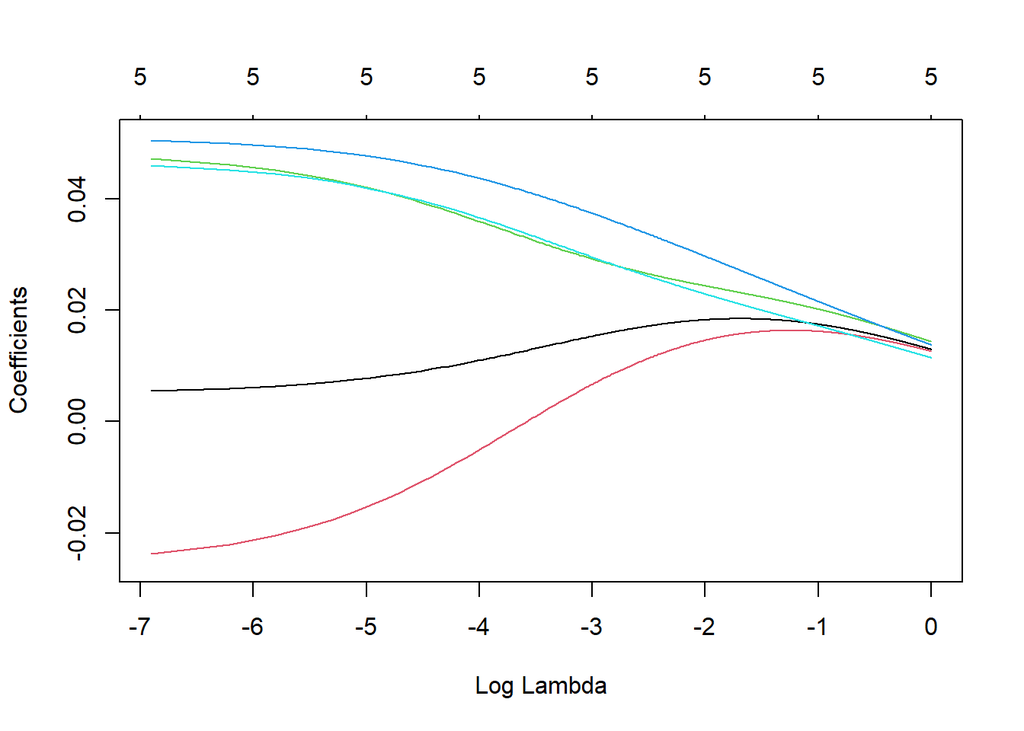

```r
plot(ridge.mod, xvar="lambda")
```

*This graph confirms pretty well the our thought that the Risk is calculate linearly.*

We want to select the best hyper parameter.

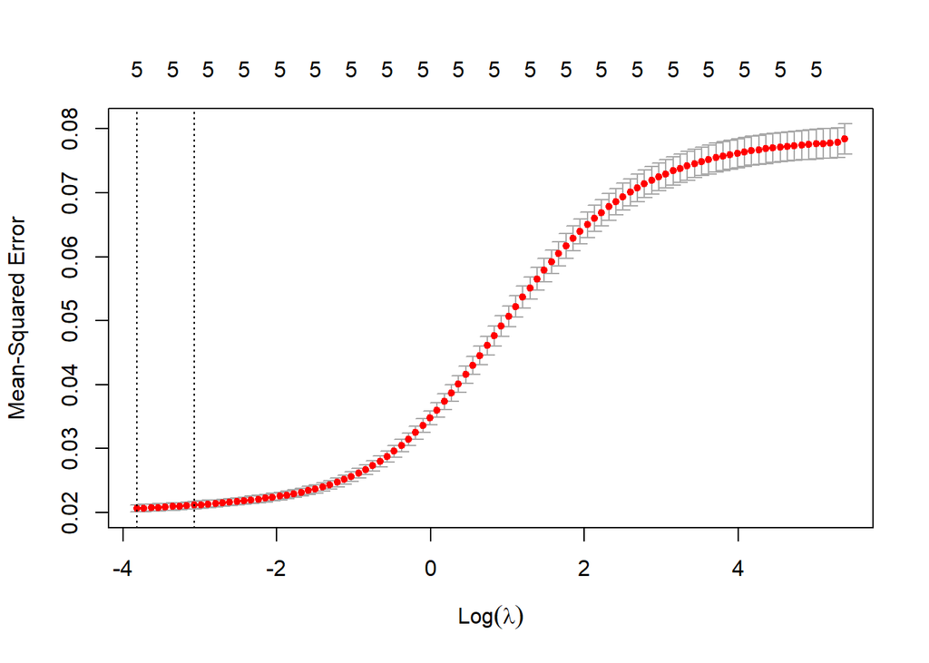

```r
ridge.cv = cv.glmnet(X, y, type.measure="mse", alpha=0)
plot(ridge.cv)
```

As we want to minimize the Mean-Square Error the best landa will be the one with the less part of the curve, it seems that it will be near -4. the log odf lamda can be between -4 and -3 aproximatevelly.

```r
opt.lambda <- ridge.cv$lambda.min
opt.lambda
```

```
## [1] 0.02187958
```

```r
lambda.index <- which(ridge.cv$lambda == ridge.cv$lambda.1se)
beta.ridge <- ridge.cv$glmnet.fit$beta[, lambda.index]
beta.ridge
```

```
##         Genetic.Risk OccuPational.Hazards chronic.Lung.Disease
##          0.014973794          0.005820389          0.029642812
##              Obesity          Alcohol.use
##          0.037956622          0.030123514
```

*We can appreciate that this model changes a little bit the coefficients*

We are going to test the model now.

```r
X.test = model.matrix(model, data=XTest)[,-1]  # skip column of ones
ridge.pred = predict(ridge.cv$glmnet.fit, s=opt.lambda, newx=X.test)
```

```r
y.test =XTest$Risk
postResample(pred = ridge.pred,  obs = y.test)
```

```
##       RMSE   Rsquared        MAE
## 63.0539216  0.7504743 60.8760212
```

*We can see that the Rsquared is considerably less than the ones obtained with the step wise regression and the step foward so if we had to predict the risk f a Patient we would use the ones mentioned.*

We will use caret in the ridge regression in order to find something better. The caret regression changes some hyperparameters in order to find a better model.

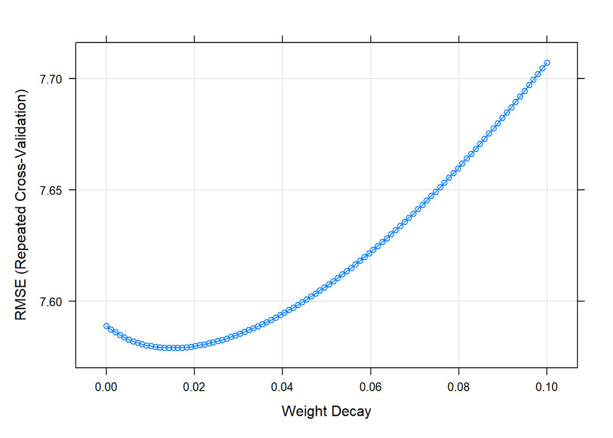

```r
# the grid for lambda
ridge_grid <- expand.grid(lambda = seq(0, .1, length = 100))

# train
ridge_tune <- train(modelall, data = XTrain,
                    method='ridge',
                    preProc=c('scale','center'),
                    tuneGrid = ridge_grid, trControl=ctrl)

plot(ridge_tune)
```

**We look for the best tune, with caret.**

```r
ridge_tune$bestTune
```

```
##        lambda
## 16 0.01515152
```

**We make the prediction for this model.**

```r
test_results$ridge <- predict(ridge_tune, XTest)
postResample(pred = test_results$ridge,  obs = test_results$Risk)
```

```
##      RMSE  Rsquared       MAE
## 7.4324504 0.8008706 6.0125401
```

*We can now see the accuracy that we had before a slightly better one. The Rsquared and the RMSE are lower and higher thna the foward regression even if they are very simila, we are going to use Foward regression.*

### LASSO

The LASSO technique which variables selection and approximation in order to determine a better prediction.

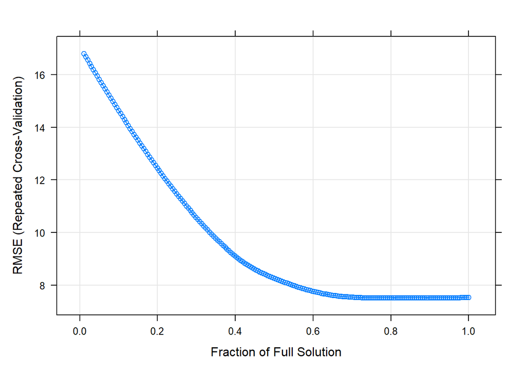

```r
lasso_grid <- expand.grid(fraction = seq(.01, 1, length = 200))
lasso_tune <- train(modelall, data = XTrain,
                    method='lasso',
                    preProc=c('scale','center'),
                    tuneGrid = lasso_grid, trControl = ctrl)
plot(lasso_tune)
```

**We look for the best hyper parameters**

```r
lasso_tune$bestTune
```

```
##      fraction
## 162 0.8109548
```

**We use them now to make the prediction.**

```r
test_results$lasso <- predict(lasso_tune, XTest)
postResample(pred = test_results$lasso,  obs = test_results$Risk)
```

```
##      RMSE  Rsquared       MAE
## 7.4305000 0.8004886 5.9923061
```

*We have less RSquared than with ridge regression, this is maybe due because of the fact that we have tried less hyper-parameters.*

### ELASTIC REGRESSION

This method combines the lasso and ridge method it shoud have better Rsquared results.

```r
modelLookup('glmnet')
```

```
##    model parameter                    label forReg forClass probModel
## 1 glmnet     alpha        Mixing Percentage   TRUE     TRUE      TRUE
## 2 glmnet    lambda Regularization Parameter   TRUE     TRUE      TRUE
```

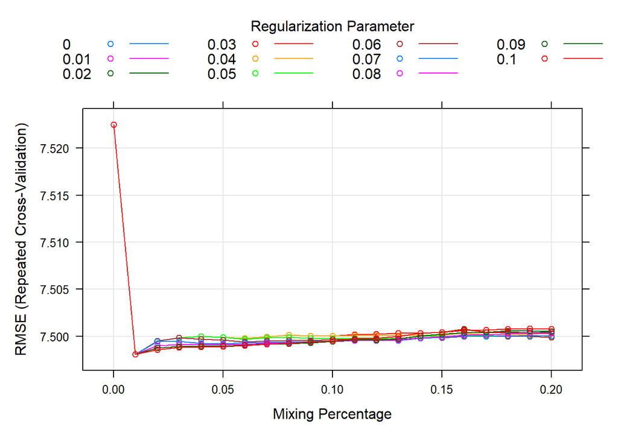

```r
elastic_grid = expand.grid(alpha = seq(0, .2, 0.01), lambda = seq(0, .1, 0.01))

glmnet_tune <- train(modelall, data = XTrain,
                     method='glmnet',
                     preProc=c('scale','center'),
                     tuneGrid = elastic_grid, trControl = ctrl)

plot(glmnet_tune)
```

**We search for the best hyper-parameters**

```r
glmnet_tune$bestTune
```

```
##    alpha lambda
## 22  0.01    0.1
```

**We look for the prediction .**

```r
test_results$glmnet <- predict(glmnet_tune, XTest)
postResample(pred = test_results$glmnet,  obs = test_results$Risk)
```

```
##      RMSE  Rsquared       MAE
## 7.4134222 0.8014731 6.0151713
```

We can see which vvariables are relevant in this case.

```r
lr_imp <- varImp(back_tune , scale = F)
plot(lr_imp, scales = list(y = list(cex = .95)))
```

## MACHINE LEARNING

After the statistical tools, we use the Machine Learning ones. We could think :

*Which is the diffrence?*

In fact for statistical tools we can trace back how the calculus were done, with machine learning we only have the result.

#### KNN

This way of studing regression searches for the nearest neighbors and make calculus from there.

```r
modelLookup('kknn')
```

```
##   model parameter           label forReg forClass probModel
## 1  kknn      kmax Max. #Neighbors   TRUE     TRUE      TRUE
## 2  kknn  distance        Distance   TRUE     TRUE      TRUE
## 3  kknn    kernel          Kernel   TRUE     TRUE      TRUE
```

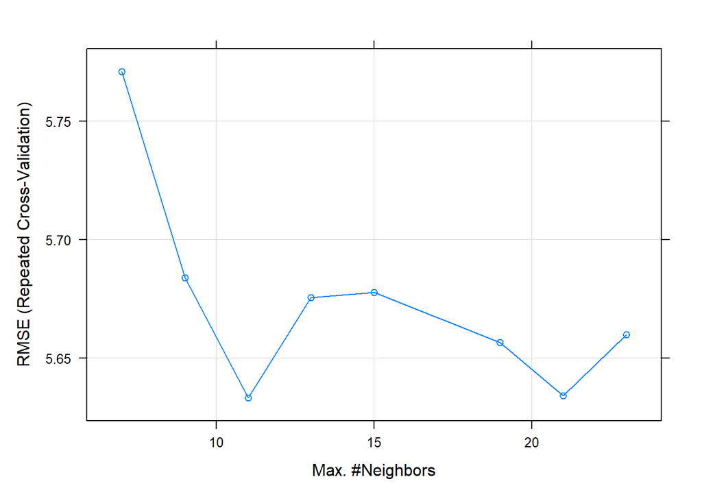

```r
knn_tune <- train(modelall,
                  data = XTrain,
                  method = "kknn",
                 preProc=c('scale','center'),
                  tuneGrid = data.frame(kmax=c(7,9,11,13,15,19,21,23),distance=2,kernel='optimal'),
                 trControl = ctrl)
plot(knn_tune)
```

*We now make the prediction*

```r
test_results$knn <- predict(knn_tune, XTest)
postResample(pred = test_results$knn,  obs = test_results$Risk)
```

```
##      RMSE  Rsquared       MAE
## 5.5663849 0.8880196 3.3773722
```

*We can clearly see that the the RSquared is much higher and the RSMe is lower. This is a much better model.*

```r
lr_imp <- varImp(knn_tune, scale = F)
plot(lr_imp, scales = list(y = list(cex = .95)))
```

[output not shown]

### RANDOM FOREST

We have already use the random forest for classification, this time we will use it for Regression.

```r
rf_tune <- train(modelall,
                 data = XTrain,
                 method = "rf",
                 preProc=c('scale','center'),
                 ntree = 200,
                 importance = TRUE, trControl = ctrl)
```

```r
test_results$rf <- predict(rf_tune, XTest)
postResample(pred = test_results$rf,  obs = test_results$Risk)
```

```
##      RMSE  Rsquared       MAE
## 5.3793042 0.8957373 3.1456740
```

*We have the best RSquared for the moment. Once again it is more difficult to understand the calculations. But we can plot the relevant variables to understand it better. We suppose that the variable importance should be the same than for the classification part.*

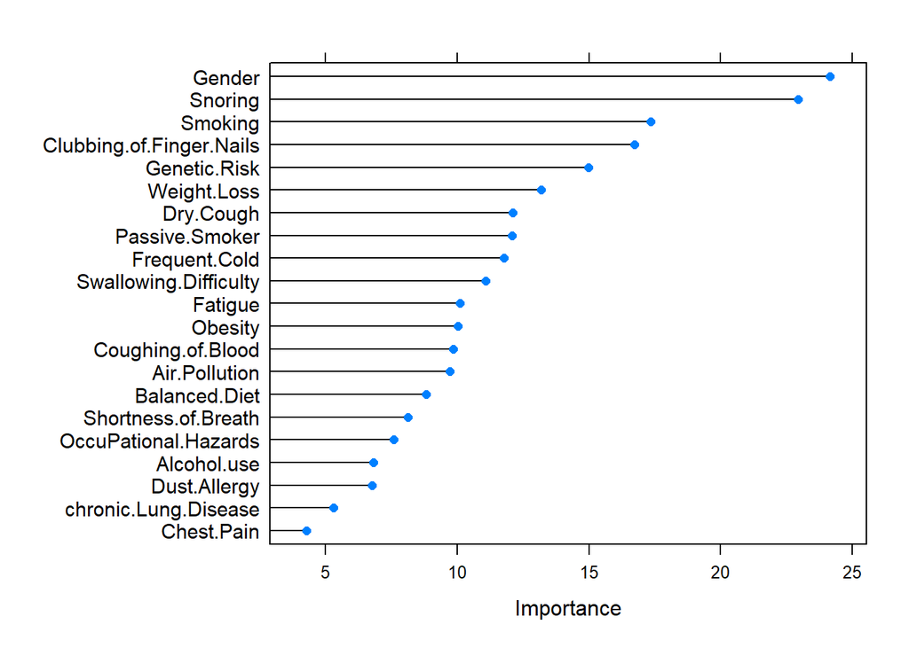

```r
lr_imp <- varImp(rf_tune, scale = F)
plot(lr_imp, scales = list(y = list(cex = .95)))
```

*It is very interesting to see that except the genetic Risk the other variables are changing positions. That is a good example of how 2 machine learning methods obtain similar results using totally different ways. Nevertheless the more relevant variables are still similar. It is interestuing to see that now smokekings ir more relevant thant passive smoking.*

### GRADIENT BOOSTING recurssion

```r
xgb_tune <- train(modelall,
                  data = XTrain,
                  method = "xgbTree",
                  preProc=c('scale','center'),
                  #objective="reg:squarederror",
                  trControl = ctrl,
                  tuneGrid = expand.grid(nrounds = c(10,300), max_depth = c(5,6,7), eta=c(0.01,0.1, 1),gamma = c(1, 2, 3), colsample_bytree = c(1, 2),min_child_weight = c(1), subsample = c(0.2,0.5,0.8)))
```

```r
test_results$xgb <- predict(xgb_tune, XTest)

postResample(pred = test_results$xgb,  obs = test_results$Risk)
```

```
##      RMSE  Rsquared       MAE
## 5.3966564 0.8949586 3.1529615
```

### CONCLUSION REGRESSION

After seeing all the differents techniques we are able to compare them and predict the results in the best way possible. Selecting the methods with the least mean squared error we are going to cgoose the predictors, and finally predict the data.

```r
apply(test_results[-1], 2, function(x) mean(abs(x - test_results$Risk)))
```

```
##       lm      alm      seq       bw    ridge    lasso   glmnet      knn
## 6.202402 6.202402 6.157958 6.021679 6.012540 5.992306 6.015171 3.377372
##       rf      xgb
## 3.145674 3.152961
```

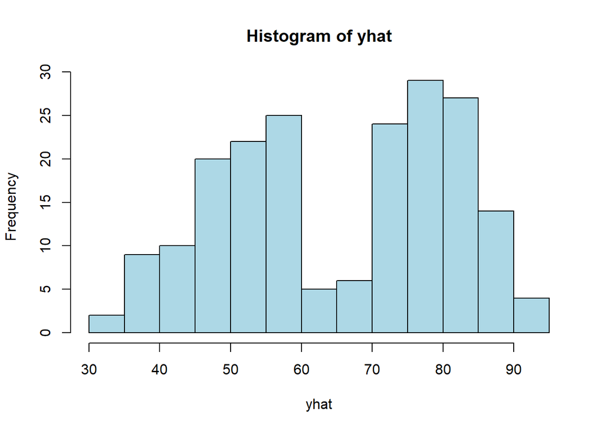

```r
test_results$comb = ( test_results$knn + test_results$rf+ test_results$xgb)/3
yhat = (test_results$comb)
hist(yhat, col="lightblue")
```

We can see that the results are kind of symmetric which is a good thing. It has alot of similitudes with the density of Risk that we plotted at the beggining. So we are going to consider those results as usefull. We are now going to compute the incertitude to know how accurate was our prediction.

We look for the incertitude limits, it will be useful for plotting the results.

```r
y = test_results$Risk
error = y-yhat
noise = error[1:100]
lwr = yhat[101:length(yhat)] + quantile(noise,0.05, na.rm=T)
upr = yhat[101:length(yhat)] + quantile(noise,0.95, na.rm=T)
predictions = data.frame(real=y[101:length(y)], fit=yhat[101:length(yhat)], lwr=lwr, upr=upr)
predictions = predictions %>% mutate(out=factor(if_else(real<lwr | real>upr,1,0)))
```

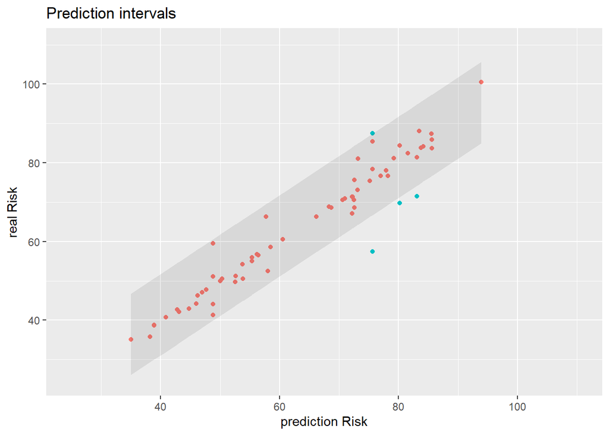

```r
ggplot(predictions, aes(x=fit, y=real))+
  geom_point(aes(color=out)) + theme(legend.position="none") +
  xlim(25, 110) + ylim(25, 110) + geom_ribbon(data=predictions,aes(ymin=lwr,ymax=upr),alpha=0.1) +
  labs(title = "Prediction intervals", x = "prediction Risk",y="real Risk")
```

*We can see that we have very very accurate predictions, this can be explained as we will do in the conclusion because of us taking into creating the Risk variable*

In conlusion we can say that the work we have done with all kinds of regression has lead us to best approaches. Those ones have led us to a good prediction with the help of the linearity that the Risk seems to have with the data.

**It is relevant to say that the best approach are the ones of machine learning but their are more difficult to understand.**

# CONCLUSION

First thing we can say is that as we thought the lineal model is very well predicted. But nevertheless the accuracy is very similar between the Levels of Risk and the Risk which shows that the risk computed is pretty realistic.

Moreover, In most of the cases the relevant values are the ones with a higher coefficient in the linear model created at the begging. That shows once again how good the model is predicted.

In fact this exercise, is very interesting. **We could thing why if we have created a linear dependent variable we are not able to find a perfect result?**

This is interesting and it was not easy to find an answer.But we can think of an explanation. The Risk variable was the first think we introduced. After that step, we introduced the NA’s to be able to correct them. As a result we had some variables of Risk that were not perfectly linear. And if we would have done or work very good those NA’s replaced shouldn’t be seen. But the replacement of NA’ s is not always perfect. We can then suppose that the Values outside are some of the ones with NA’s.

**That shows the relevance of replacing NA’s in a good way**

### Sources

As for the previous work, we have taken some of the code presented in the practical cases explaining the different approaches.

pictures: Is source not precised, source Wikipedia

dataset: Kaggle